# J Component

## 19BCE1459 - Meghna Manoj Nair

## 19BCE1182 - Gadiparthy Harika Sai

## Dataset Used

slope (type: int) - the slope of the peak exercise ST segment, an electrocardiography read out indicating quality of blood flow to the heart – Value 1: upsloping – Value 2: flat – Value 3: downsloping

thal (type: categorical) - results of thallium stress test measuring blood flow to the heart, with possible – 1: normal – 2: fixed defect – 3: reversable defect

trestbps (type: int) - resting blood pressure

cp (type: int): chest pain type (4 values) – Value 0: typical angina – Value 1: atypical angina – Value 2: non-anginal pain  
– Value 3: asymptomatic

fbs (type: binary) - fasting blood sugar > 120 mg/dl

restecg (type: int) - resting electrocardiographic results (values 0,1,2)

oldpeak (type: float) - oldpeak = ST depression induced by exercise relative to rest, a measure of abnormality in electrocardiograms

sex (type: binary) - 0: female, 1: male

age (type: int) - age in years

exang: exercise_induced_angina (type: binary) - exercise-induced chest pain (0: False, 1: True)

chol (type: int) - serum cholestoral in mg/dl

thalach (type: int) - maximum heart rate achieved

ca (type: categorical) - number of major vessels (0-4) colored by flourosopy

target (type: categorical) - diagnosis of heart disease (angiographic disease status) – Value 0: < 50% diameter narrowing – Value 1: > 50% diameter narrowing

## Loading the dataset

```r
library(kableExtra)
library(rsample)
library(recipes)
library(parsnip)
library(yardstick)
library(viridisLite)
library(GGally)
rm(list=ls())
library(tidyverse)
heart <- read.csv("heart.csv")
#View(heart)
any(is.na(heart))
```

```
## [1] FALSE
```

```r
str(heart)
```

```
## 'data.frame':    2175 obs. of  14 variables:
##  $ ï..age  : int  63 37 41 56 57 57 56 44 52 57 ...
##  $ sex     : int  1 1 0 1 0 1 0 1 1 1 ...
##  $ cp      : int  3 2 1 1 0 0 1 1 2 2 ...
##  $ trestbps: int  145 130 130 120 120 140 140 120 172 150 ...
##  $ chol    : int  233 250 204 236 354 192 294 263 199 168 ...
##  $ fbs     : int  1 0 0 0 0 0 0 0 1 0 ...
##  $ restecg : int  0 1 0 1 1 1 0 1 1 1 ...
##  $ thalach : int  150 187 172 178 163 148 153 173 162 174 ...
##  $ exang   : int  0 0 0 0 1 0 0 0 0 0 ...
##  $ oldpeak : num  2.3 3.5 1.4 0.8 0.6 0.4 1.3 0 0.5 1.6 ...
##  $ slope   : int  0 0 2 2 2 1 1 2 2 2 ...
##  $ ca      : int  0 0 0 0 0 0 0 0 0 0 ...
##  $ thal    : int  1 2 2 2 2 1 2 3 3 2 ...
##  $ target  : int  1 1 1 1 1 1 1 1 1 1 ...
```

```r
head(heart)
```

```
##   ï..age sex cp trestbps chol fbs restecg thalach exang oldpeak slope ca thal
## 1     63   1  3      145  233   1       0     150     0     2.3     0  0    1
## 2     37   1  2      130  250   0       1     187     0     3.5     0  0    2
## 3     41   0  1      130  204   0       0     172     0     1.4     2  0    2
## 4     56   1  1      120  236   0       1     178     0     0.8     2  0    2
## 5     57   0  0      120  354   0       1     163     1     0.6     2  0    2
## 6     57   1  0      140  192   0       1     148     0     0.4     1  0    1
##   target
## 1      1
## 2      1
## 3      1
## 4      1
## 5      1
## 6      1
```

```r
tail(heart)
```

```
##      ï..age sex cp trestbps chol fbs restecg thalach exang oldpeak slope ca
## 2170     58   1  0      150  270   0       0     111     1     0.8     2  0
## 2171     68   1  2      180  274   1       0     150     1     1.6     1  0
## 2172     62   0  0      160  164   0       0     145     0     6.2     0  3
## 2173     52   1  0      128  255   0       1     161     1     0.0     2  1
## 2174     59   1  0      110  239   0       0     142     1     1.2     1  1
## 2175     60   0  0      150  258   0       0     157     0     2.6     1  2
##      thal target
## 2170    3      0
## 2171    3      0
## 2172    3      0
## 2173    3      0
## 2174    3      0
## 2175    3      0
```

```r
summary(heart)
```

```
##      ï..age           sex               cp           trestbps
##  Min.   :29.00   Min.   :0.0000   Min.   :0.000   Min.   : 94.0
##  1st Qu.:46.00   1st Qu.:0.0000   1st Qu.:0.000   1st Qu.:120.0
##  Median :54.00   Median :1.0000   Median :1.000   Median :130.0
##  Mean   :53.51   Mean   :0.6331   Mean   :1.149   Mean   :130.2
##  3rd Qu.:60.00   3rd Qu.:1.0000   3rd Qu.:2.000   3rd Qu.:140.0
##  Max.   :77.00   Max.   :1.0000   Max.   :3.000   Max.   :200.0
##       chol            fbs            restecg          thalach
##  Min.   :126.0   Min.   :0.0000   Min.   :0.0000   Min.   : 71.0
##  1st Qu.:209.0   1st Qu.:0.0000   1st Qu.:0.0000   1st Qu.:143.0
##  Median :236.0   Median :0.0000   Median :1.0000   Median :158.0
##  Mean   :243.7   Mean   :0.1366   Mean   :0.5287   Mean   :154.5
##  3rd Qu.:269.0   3rd Qu.:0.0000   3rd Qu.:1.0000   3rd Qu.:170.0
##  Max.   :564.0   Max.   :1.0000   Max.   :2.0000   Max.   :202.0
##      exang           oldpeak           slope             ca
##  Min.   :0.0000   Min.   :0.0000   Min.   :0.000   Min.   :0.0000
##  1st Qu.:0.0000   1st Qu.:0.0000   1st Qu.:1.000   1st Qu.:0.0000
##  Median :0.0000   Median :0.5000   Median :2.000   Median :0.0000
##  Mean   :0.2317   Mean   :0.8516   Mean   :1.486   Mean   :0.5402
##  3rd Qu.:0.0000   3rd Qu.:1.4000   3rd Qu.:2.000   3rd Qu.:1.0000
##  Max.   :1.0000   Max.   :6.2000   Max.   :2.000   Max.   :4.0000
##       thal           target
##  Min.   :0.000   Min.   :0.0000
##  1st Qu.:2.000   1st Qu.:1.0000
##  Median :2.000   Median :1.0000
##  Mean   :2.242   Mean   :0.7586
##  3rd Qu.:3.000   3rd Qu.:1.0000
##  Max.   :3.000   Max.   :1.0000
```

## Converting the values 0 and 1 in sex to female and male respectively

```r
heart <- heart%>%
  mutate(sex=gsub("0","Female",sex))%>%
  mutate(sex=gsub("1","Male",sex))
head(heart$sex)
```

```
## [1] "Male"   "Male"   "Female" "Male"   "Female" "Male"
```

## Checking the count of males and females prone to heart disease

```r
library(dplyr)
heart%>%
  filter(target==1)%>%
  group_by(sex)%>%
  summarize(No.of_people_prone_to_heart_disease=sum(target))
```

```
## # A tibble: 2 x 2
##   sex    No.of_people_prone_to_heart_disease
##   <chr>                                <int>
## 1 Female                                 720
## 2 Male                                   930
```

## Average cholestrol level of the people prone to heart disease

```r
heart%>%
  filter(target==1)%>%
  summarize(Avg.cholestrol=mean(chol))
```

```
##   Avg.cholestrol
## 1       242.2303
```

## Relation between chest pain type and target

```r
library(crosstable)
source("http://pcwww.liv.ac.uk/~william/R/crosstab.r")
crosstab(heart,row.vars= "cp",col.vars = "target")
```

```
##     target    0    1  Sum
## cp
## 0           401  390  791
## 1            27  410  437
## 2            90  690  780
## 3             7  160  167
## Sum         525 1650 2175
```

Inference: It can be observed from the above crosstable that for the given dataset, people with chest pain type 2 (i.e Non Anginal Pain) are more likely to be prone to a heart disease when compared to those people who have a chest pain of type 0 (i.e Typical Angina) who are not likely to be exposed to a heart disease.

## Relation between Sex and Target

```r
crosstab(heart,row.vars = "sex",col.vars = "target")
```

```
##        target    0    1  Sum
## sex
## Female          78  720  798
## Male           447  930 1377
## Sum            525 1650 2175
```

## Data Transformation

```r
data2 <- heart%>%
  mutate(fbs=if_else(fbs==1,">120","<=120"),
         exang=if_else(exang==1,"YES","NO"),
         cp=if_else(cp==1,"ATYPICAL ANGINA",
                    if_else(cp==2,"NON-ANGINAL PAIN",ifelse(cp==0,"TYPICAL ANGINA","ASYMPTOMATIC"))),
         restecg=if_else(restecg==0,"NORMAL",
                         if_else(restecg==1,"ABNORMALITY","PROBABLE OR DEFINITE")),
         slope=as.factor(slope),
         ca=as.factor(ca),
         thal=as.factor(thal),
         target=if_else(target==1,"YES","NO"))%>%
         mutate_if(is.character,as.factor)%>%
         rename(age=ï..age)%>%
         dplyr::select(target,sex,fbs,exang,cp,restecg,slope,ca,thal,everything())

#View(data2)
head(data2)
```

```
##   target    sex   fbs exang               cp     restecg slope ca thal age
## 1    YES   Male  >120    NO     ASYMPTOMATIC      NORMAL     0  0    1  63
## 2    YES   Male <=120    NO NON-ANGINAL PAIN ABNORMALITY     0  0    2  37
## 3    YES Female <=120    NO  ATYPICAL ANGINA      NORMAL     2  0    2  41
## 4    YES   Male <=120    NO  ATYPICAL ANGINA ABNORMALITY     2  0    2  56
## 5    YES Female <=120   YES   TYPICAL ANGINA ABNORMALITY     2  0    2  57
## 6    YES   Male <=120    NO   TYPICAL ANGINA ABNORMALITY     1  0    1  57
##   trestbps chol thalach oldpeak
## 1      145  233     150     2.3
## 2      130  250     187     3.5
## 3      130  204     172     1.4
## 4      120  236     178     0.8
## 5      120  354     163     0.6
## 6      140  192     148     0.4
```

## Data Visualization

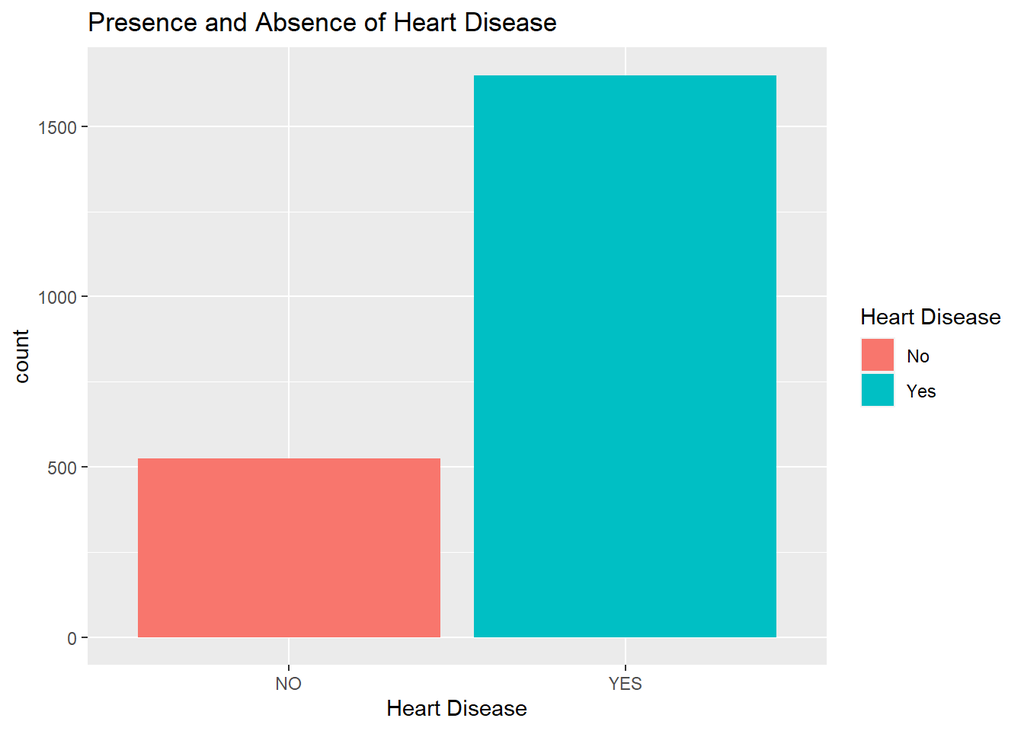

```r
library(ggplot2)
ggplot(data2,aes(x=target,fill=target))+
  geom_bar()+
  xlab("Heart Disease")+
  ylab("count")+
  ggtitle("Presence and Absence of Heart Disease")+
  scale_fill_discrete(name='Heart Disease',labels=c("No","Yes"))
```

* * *

Inference: It can be observed from the above graph that from the given dataset, more people are prone towards having a pathological disease and fewer number of patients are likely to escape from the same.

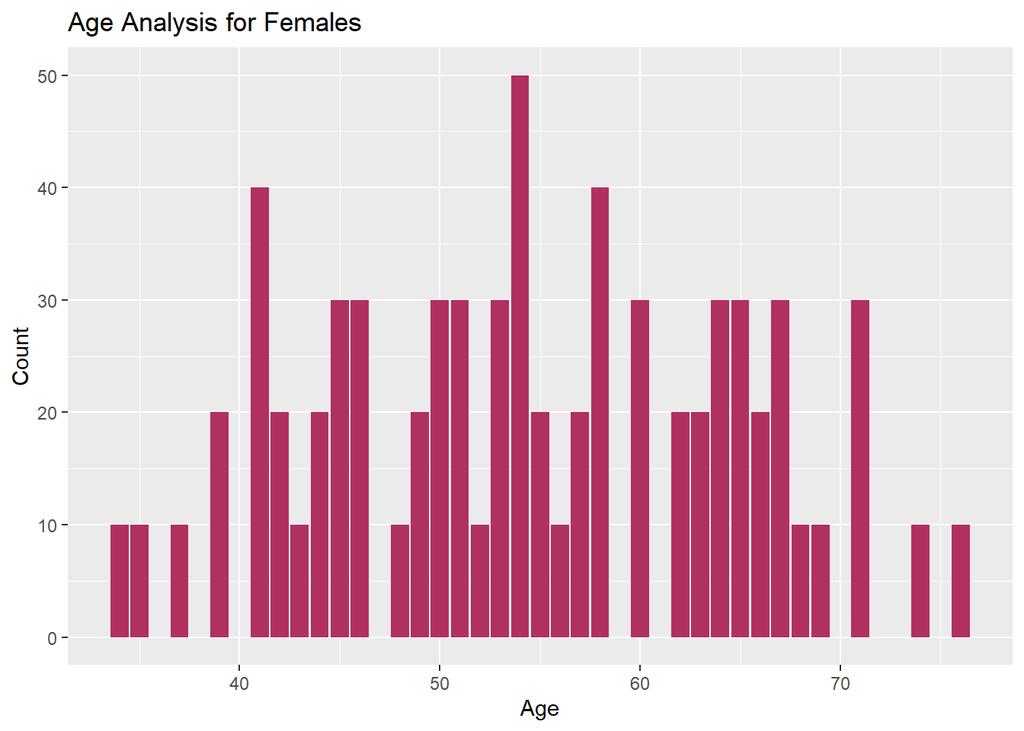

```r
data2%>%
  filter(sex=="Female")%>%
  filter(target=="YES")%>%
  group_by(age)%>%
  count()%>%
  ggplot()+
  geom_col(aes(age,n),fill='maroon')+
  ggtitle("Age Analysis for Females")+
  xlab("Age")+
  ylab("Count")
```

* * *

Inference: It can be inferred that females within the age group of 40 to 60 are more prone to pathological diseases when compared to the rest of the age groups.

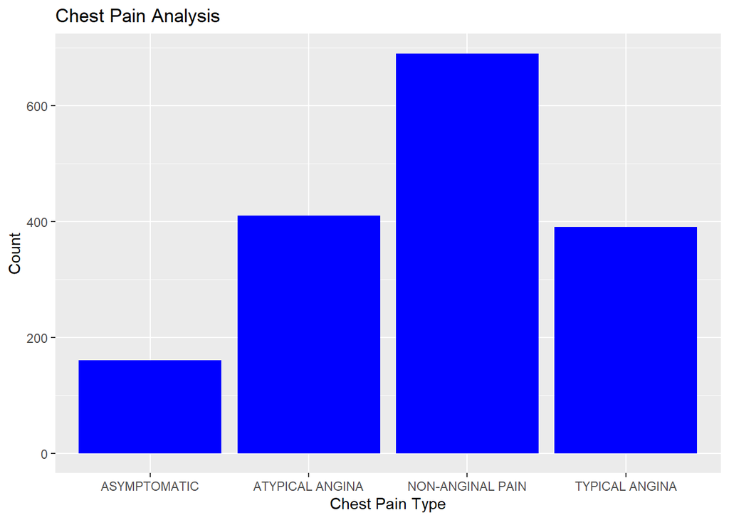

```r
data2%>%
  filter(target=="YES")%>%
  group_by(cp)%>%
  count()%>%
  ggplot()+
  geom_col(aes(cp,n),fill='blue')+
  ggtitle("Chest Pain Analysis")+
  xlab("Chest Pain Type")+
  ylab("Count")
```

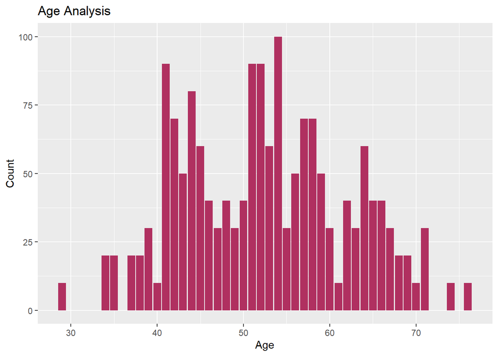

```r
#count the frequency of the values of age
data2%>%
  filter(target=="YES")%>%
  group_by(age)%>%
  count()%>%
  ggplot()+
  geom_col(aes(age,n),fill='maroon')+
  ggtitle("Age Analysis")+
  xlab("Age")+
  ylab("Count")
```

* * *

## Compare BP across chest pain

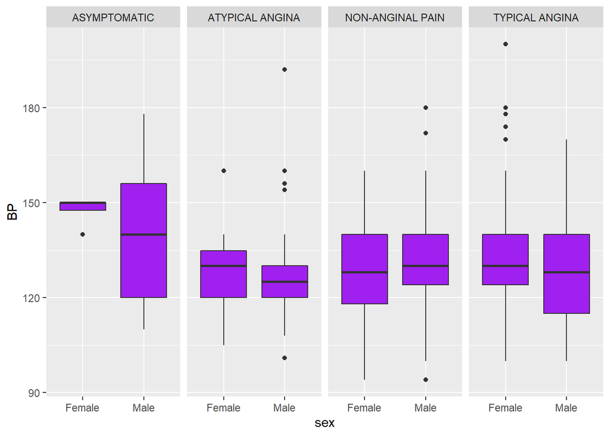

```r
data2%>%
  ggplot(aes(x=sex,y=trestbps))+
  geom_boxplot(fill='purple')+
  xlab('sex')+
  ylab('BP')+
  facet_grid(~cp)
```

Inference: The above given facet_wrapped box plot gives the various central dispersion techniques for the four types of chest pains with regards to blood pressure for both males and females. For asymptomatic chest pain, females are likely to have a higher BP when compared to male and the same can be observed for atypical anginal chest pain also. However, in the non-anginal chest pain, males are likely to have a higher BP when compared to females.

## Comparing cholestrol across chest pain

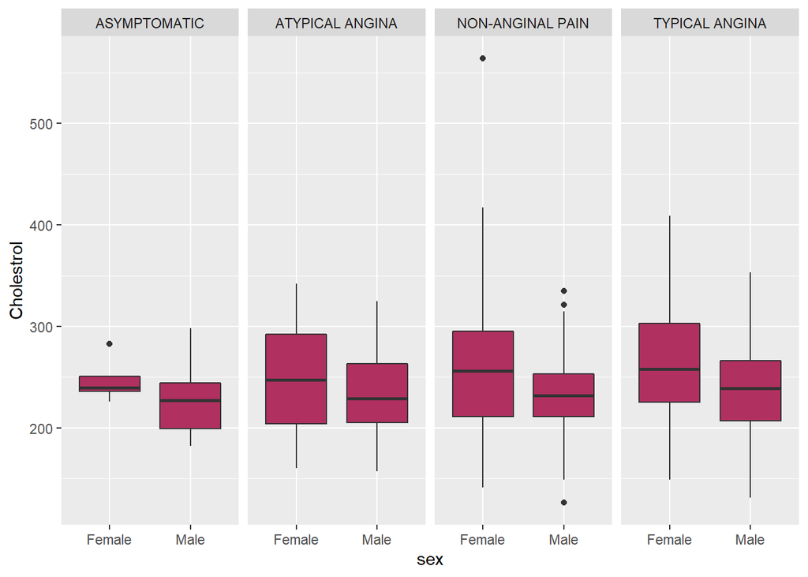

```r
data2%>%
  ggplot(aes(x=sex,y=chol))+
  geom_boxplot(fill='maroon')+
  xlab('sex')+
  ylab('Cholestrol')+
  facet_grid(~cp)
```

* * *

Inference: The above given facet_wrapped box plot gives the various central dispersion techniques for the four types of chest pains with regards to cholestrol for both males and females. For typical, atypical angina and non-anginal chest pain, females are likely to have a higher cholestrol level when compared to their male counterparts.

## Correlation Plot

```r
library(corrplot)
corheart <- cor(data2[,10:14])
corheart
```

```
##                 age    trestbps         chol      thalach      oldpeak
## age       1.0000000  0.29901088  0.265510159 -0.458739508  0.221695483
## trestbps  0.2990109  1.00000000  0.130032229 -0.045295081  0.238795505
## chol      0.2655102  0.13003223  1.000000000 -0.002173974 -0.002252742
## thalach  -0.4587395 -0.04529508 -0.002173974  1.000000000 -0.291106984
## oldpeak   0.2216955  0.23879551 -0.002252742 -0.291106984  1.000000000
```

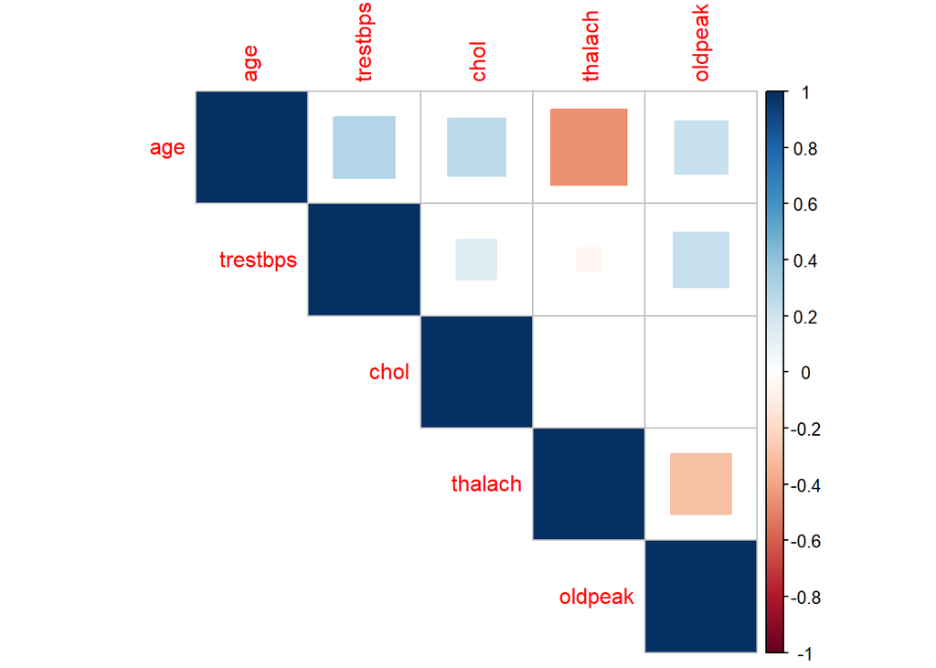

```r
corrplot(corheart,method='square',type='upper')
```

## Visualization of heart disease predictions

```r
library(dplyr)
heartdata <- data2 %>%
mutate_at(c("restecg",
                "fbs",
                "sex",
                "target",
                "exang",
                "slope",
                "cp"), as_factor) %>%
  select(age,
           trestbps,
           chol,
           thalach,
           oldpeak,
           ca,
           everything())

heartdata %>%
  glimpse()
```

```
## Rows: 2,175
## Columns: 14
## $ age      <int> 63, 37, 41, 56, 57, 57, 56, 44, 52, 57, 54, 48, 49, 64, 58, 5~
## $ trestbps <int> 145, 130, 130, 120, 120, 140, 140, 120, 172, 150, 140, 130, 1~
## $ chol     <int> 233, 250, 204, 236, 354, 192, 294, 263, 199, 168, 239, 275, 2~
## $ thalach  <int> 150, 187, 172, 178, 163, 148, 153, 173, 162, 174, 160, 139, 1~
## $ oldpeak  <dbl> 2.3, 3.5, 1.4, 0.8, 0.6, 0.4, 1.3, 0.0, 0.5, 1.6, 1.2, 0.2, 0~
## $ ca       <fct> 0, 0, 0, 0, 0, 0, 0, 0, 0, 0, 0, 0, 0, 0, 0, 0, 0, 0, 0, 2, 0~
## $ target   <fct> YES, YES, YES, YES, YES, YES, YES, YES, YES, YES, YES, YES, Y~
## $ sex      <fct> Male, Male, Female, Male, Female, Male, Female, Male, Male, M~
## $ fbs      <fct> >120, <=120, <=120, <=120, <=120, <=120, <=120, <=120, >120, ~
## $ exang    <fct> NO, NO, NO, NO, YES, NO, NO, NO, NO, NO, NO, NO, NO, YES, NO,~
## $ cp       <fct> ASYMPTOMATIC, NON-ANGINAL PAIN, ATYPICAL ANGINA, ATYPICAL ANG~
## $ restecg  <fct> NORMAL, ABNORMALITY, NORMAL, ABNORMALITY, ABNORMALITY, ABNORM~
## $ slope    <fct> 0, 0, 2, 2, 2, 1, 1, 2, 2, 2, 2, 2, 2, 1, 2, 1, 2, 0, 2, 2, 1~
## $ thal     <fct> 1, 2, 2, 2, 2, 1, 2, 3, 3, 2, 2, 2, 2, 2, 2, 2, 2, 2, 2, 2, 3~
```

```r
data3 <- heartdata%>%
  select(sex,
         cp,
         fbs,
         restecg,
         exang,
         slope,
         ca,
         thal,
         target)%>%
  mutate(sex = recode_factor(sex, `Female` = "female",
                                  `Male` = "male" ),
         cp = recode_factor(cp, `1` = "ATYPICAL ANGINA",
                                `2` = "NON-ANGINAL PAIN",
                                `3` = "ASYMPTOMATIC",
                                `0` = "TYPICAL ANGINA"),
         fbs = recode_factor(fbs, `0` = "<= 120 mg/dl",
                                  `1` = "> 120 mg/dl"),
         restecg = recode_factor(restecg, `0` = "NORMAL",
                                          `1` = "ABNORMALITY",
                                          `2` = "PROBABLE OR DEFINITE"),
         exang = recode_factor(exang, `0` = "NO",
                                      `1` = "YES"),
         slope = recode_factor(slope, `0` = "up-sloaping",
                                      `1` = "flat",
                                      `2` = "down-sloaping"),
         thal = recode_factor(thal, `0` = "normal",
                                    `1` = "normal",
                                    `2` = "fixed defect",
                                    `3` = "reversible defect")) %>%
  gather(key = "key", value = "value", -target)
```

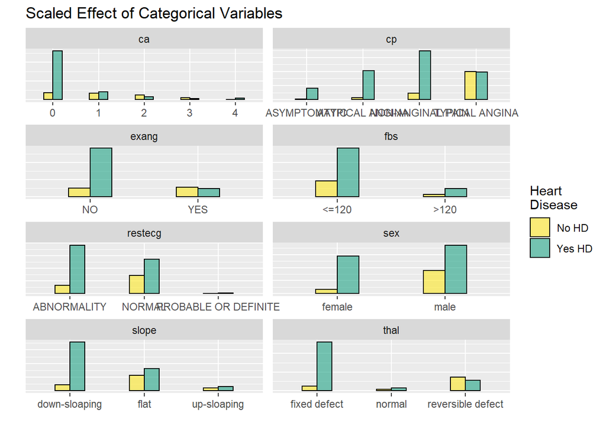

```r
#Visualize with bar plot
data3%>%
  ggplot(aes(value)) +
    geom_bar(aes(x        = value,
                 fill     = target),
                 alpha    = .6,
                 position = "dodge",
                 color    = "black",
                 width    = .4
             ) +
    labs(x = "",
         y = "",
         title = "Scaled Effect of Categorical Variables") +
    theme(
         axis.text.y  = element_blank(),
         axis.ticks.y = element_blank()) +
    facet_wrap(~ key, scales = "free", nrow = 5) +
    scale_fill_manual(
         values = c("#fde725ff", "#20a486ff"),
         name   = "Heart\nDisease",
         labels = c("No HD", "Yes HD"))
```

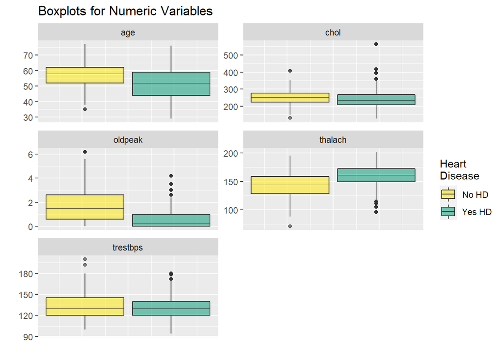

```r
data4 <- heartdata  %>%
  select(age,
         trestbps,
         chol,
         thalach,
         oldpeak,
         target) %>%
  gather(key   = "key",
         value = "value",
         -target)
#Visualize numeric variables as boxplots
data4 %>%
  ggplot(aes(y = value)) +
       geom_boxplot(aes(fill = target),
                      alpha  = .6,
                      fatten = .7) +
        labs(x = "",
             y = "",
             title = "Boxplots for Numeric Variables") +
      scale_fill_manual(
            values = c("#fde725ff", "#20a486ff"),
            name   = "Heart\nDisease",
            labels = c("No HD", "Yes HD")) +
      theme(
         axis.text.x  = element_blank(),
         axis.ticks.x = element_blank()) +
      facet_wrap(~ key,
                 scales = "free",
                 ncol   = 2)
```

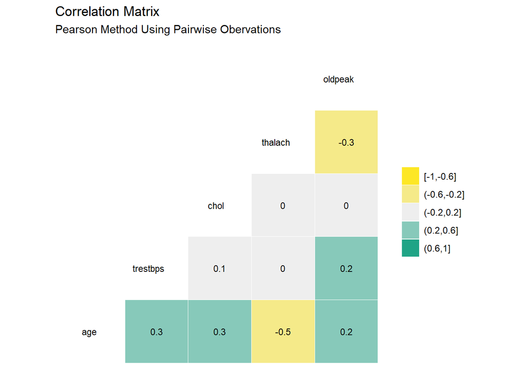

```r
heartdata %>% ggcorr(high       = "#20a486ff",
                                   low        = "#fde725ff",
                                   label      = TRUE,
                                   hjust      = .75,
                                   size       = 3,
                                   label_size = 3,
                                   nbreaks    = 5
                                              ) +
  labs(title = "Correlation Matrix",
  subtitle = "Pearson Method Using Pairwise Obervations")
```

## Decision Tree with rpart library with regards to all variables

```r
data2$target <- factor(data2$target)
set.seed(1234)
pd <- sample(2,nrow(data2),replace=TRUE,prob=c(0.8,0.2)) #80% of the data is for training and 20% of the data is for testing
train <- data2[pd==1,]
validate <- data2[pd==2,]

library(rpart)
#str(train)
head(na.omit(train))
```

```
##   target    sex   fbs exang               cp     restecg slope ca thal age
## 1    YES   Male  >120    NO     ASYMPTOMATIC      NORMAL     0  0    1  63
## 2    YES   Male <=120    NO NON-ANGINAL PAIN ABNORMALITY     0  0    2  37
## 3    YES Female <=120    NO  ATYPICAL ANGINA      NORMAL     2  0    2  41
## 4    YES   Male <=120    NO  ATYPICAL ANGINA ABNORMALITY     2  0    2  56
## 6    YES   Male <=120    NO   TYPICAL ANGINA ABNORMALITY     1  0    1  57
## 7    YES Female <=120    NO  ATYPICAL ANGINA      NORMAL     1  0    2  56
##   trestbps chol thalach oldpeak
## 1      145  233     150     2.3
## 2      130  250     187     3.5
## 3      130  204     172     1.4
## 4      120  236     178     0.8
## 6      140  192     148     0.4
## 7      140  294     153     1.3
```

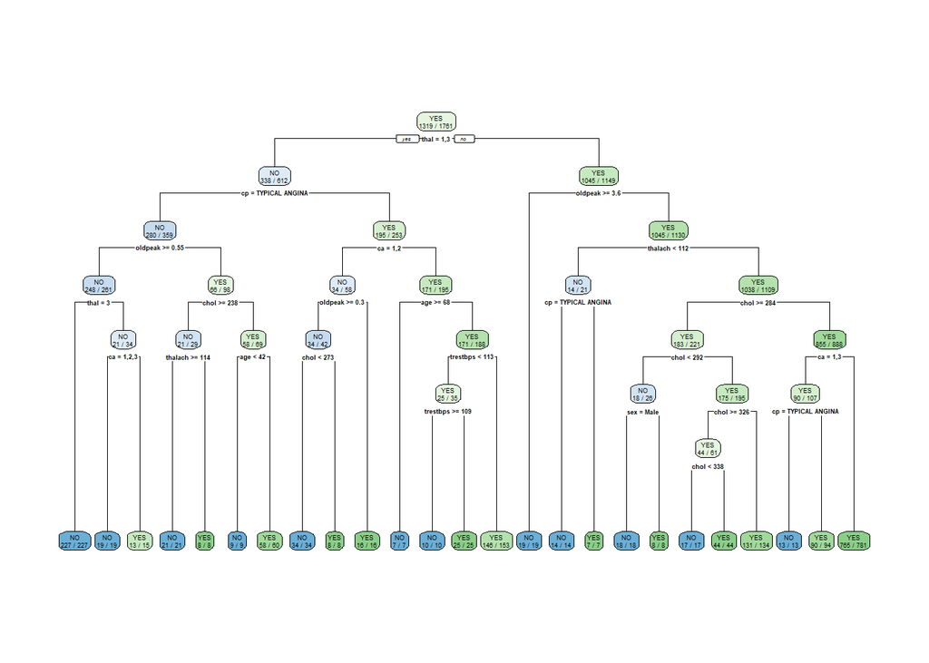

```r
tree1 <- rpart(target~., train)
library(rpart.plot)
rpart.plot(tree1,extra=2)
```

```r
#prediction
head(predict(tree1,validate))
```

```
##            NO       YES
## 5  0.00000000 1.0000000
## 14 0.02048656 0.9795134
## 16 0.02048656 0.9795134
## 26 0.02238806 0.9776119
## 28 0.02048656 0.9795134
## 29 0.00000000 1.0000000
```

## Decision Tree with rpart library with regards to thalach, oldpeak and chol

```r
data2$target <- factor(data2$target)
set.seed(1234)
pd <- sample(2,nrow(data2),replace=TRUE,prob=c(0.8,0.2)) #80% of the data is for training and 20% of the data is for testing
train <- data2[pd==1,]
validate <- data2[pd==2,]

library(rpart)
str(train)
```

```
## 'data.frame':    1761 obs. of  14 variables:
##  $ target  : Factor w/ 2 levels "NO","YES": 2 2 2 2 2 2 2 2 2 2 ...
##  $ sex     : Factor w/ 2 levels "Female","Male": 2 2 1 2 2 1 2 2 2 2 ...
##  $ fbs     : Factor w/ 2 levels "<=120",">120": 2 1 1 1 1 1 1 2 1 1 ...
##  $ exang   : Factor w/ 2 levels "NO","YES": 1 1 1 1 1 1 1 1 1 1 ...
##  $ cp      : Factor w/ 4 levels "ASYMPTOMATIC",..: 1 3 2 2 4 2 2 3 3 4 ...
##  $ restecg : Factor w/ 3 levels "ABNORMALITY",..: 2 1 2 1 1 2 1 1 1 1 ...
##  $ slope   : Factor w/ 3 levels "0","1","2": 1 1 3 3 2 2 3 3 3 3 ...
##  $ ca      : Factor w/ 5 levels "0","1","2","3",..: 1 1 1 1 1 1 1 1 1 1 ...
##  $ thal    : Factor w/ 4 levels "0","1","2","3": 2 3 3 3 2 3 4 4 3 3 ...
##  $ age     : int  63 37 41 56 57 56 44 52 57 54 ...
##  $ trestbps: int  145 130 130 120 140 140 120 172 150 140 ...
##  $ chol    : int  233 250 204 236 192 294 263 199 168 239 ...
##  $ thalach : int  150 187 172 178 148 153 173 162 174 160 ...
##  $ oldpeak : num  2.3 3.5 1.4 0.8 0.4 1.3 0 0.5 1.6 1.2 ...
```

```r
head(na.omit(train))
```

```
##   target    sex   fbs exang               cp     restecg slope ca thal age
## 1    YES   Male  >120    NO     ASYMPTOMATIC      NORMAL     0  0    1  63
## 2    YES   Male <=120    NO NON-ANGINAL PAIN ABNORMALITY     0  0    2  37
## 3    YES Female <=120    NO  ATYPICAL ANGINA      NORMAL     2  0    2  41
## 4    YES   Male <=120    NO  ATYPICAL ANGINA ABNORMALITY     2  0    2  56
## 6    YES   Male <=120    NO   TYPICAL ANGINA ABNORMALITY     1  0    1  57
## 7    YES Female <=120    NO  ATYPICAL ANGINA      NORMAL     1  0    2  56
##   trestbps chol thalach oldpeak
## 1      145  233     150     2.3
## 2      130  250     187     3.5
## 3      130  204     172     1.4
## 4      120  236     178     0.8
## 6      140  192     148     0.4
## 7      140  294     153     1.3
```

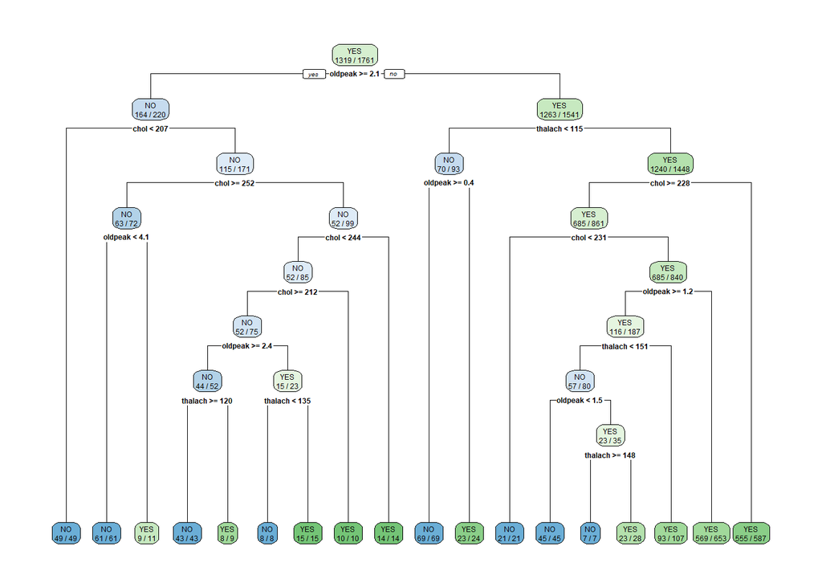

```r
tree1 <- rpart(target~thalach+oldpeak+chol, train)
library(rpart.plot)
rpart.plot(tree1,extra=2)
```

```r
#prediction
head(predict(tree1,validate))
```

```
##            NO       YES
## 5  0.12863706 0.8713629
## 14 0.05451448 0.9454855
## 16 0.05451448 0.9454855
## 26 0.12863706 0.8713629
## 28 0.05451448 0.9454855
## 29 0.12863706 0.8713629
```

## Confusion matrix for the validate data

```r
library(e1071)
library(caTools)
library(caret)
x <- naiveBayes(target ~ ., data = train)

nb_train_predict <- predict(x, validate[ , names(validate) != "target"])

cfm <- confusionMatrix(nb_train_predict, validate$target)
cfm
```

```
## Confusion Matrix and Statistics
##
##           Reference
## Prediction  NO YES
##        NO   68  23
##        YES  15 308
##
##                Accuracy : 0.9082
##                  95% CI : (0.8762, 0.9342)
##     No Information Rate : 0.7995
##     P-Value [Acc > NIR] : 1.339e-09
##
##                   Kappa : 0.7237
##
##  Mcnemar's Test P-Value : 0.2561
##
##             Sensitivity : 0.8193
##             Specificity : 0.9305
##          Pos Pred Value : 0.7473
##          Neg Pred Value : 0.9536
##              Prevalence : 0.2005
##          Detection Rate : 0.1643
##    Detection Prevalence : 0.2198
##       Balanced Accuracy : 0.8749
##
##        'Positive' Class : NO
##
```

## Analyzing the Cardiotocographic dataset with further parameters and attributes

LB: Fatal Heart Rate (type:int) - beats per minute

AC (type:float) - number of accelerations per second

FM (type:float) - number of fetal movements per second

UC (type:float) - number of uterine contraction per second

DL (type:float) - number of light decelerations per second

DS (type:categorical) - number of sever decelerations per second

DP (type:float) - number of prolonged decelerations per second

ASTV (type:int) - % of time with abnormal short term variability

MSTV (type:float) - mean value of short term variability

ALTV (type:int) - % of time with abnormal long term variability

MLTV (type:float) - mean value of long term variability

Width (type:int) - width of FHR histogram

Min (type:int) - minimum of FHR histogram

Max (type:int) - maximum of FHR histogram

Nmax (type:int) - number of histogram peaks

Nzeroes (type:int) - number of histogram zeros

Mode (type:int) - histogram mode

Mean (type:int) - histogram mean

Median (type:int) - histogram median

Variance (type:int) - histogram variance

Tendency (type:int) - histogram tendency

NSP (type:categorical) - fetal state class code –Value 1: Normal –Value 2: Suspect –Value 3: Pathological

```r
data <- read.csv("Cardiotocographic.csv")
#View(data)
str(data)
```

```
## 'data.frame':    2126 obs. of  22 variables:
##  $ LB      : int  120 132 133 134 132 134 134 122 122 122 ...
##  $ AC      : num  0 0.00638 0.00332 0.00256 0.00651 ...
##  $ FM      : num  0 0 0 0 0 0 0 0 0 0 ...
##  $ UC      : num  0 0.00638 0.00831 0.00768 0.00814 ...
##  $ DL      : num  0 0.00319 0.00332 0.00256 0 ...
##  $ DS      : num  0 0 0 0 0 0 0 0 0 0 ...
##  $ DP      : num  0 0 0 0 0 ...
##  $ ASTV    : int  73 17 16 16 16 26 29 83 84 86 ...
##  $ MSTV    : num  0.5 2.1 2.1 2.4 2.4 5.9 6.3 0.5 0.5 0.3 ...
##  $ ALTV    : int  43 0 0 0 0 0 0 6 5 6 ...
##  $ MLTV    : num  2.4 10.4 13.4 23 19.9 0 0 15.6 13.6 10.6 ...
##  $ Width   : int  64 130 130 117 117 150 150 68 68 68 ...
##  $ Min     : int  62 68 68 53 53 50 50 62 62 62 ...
##  $ Max     : int  126 198 198 170 170 200 200 130 130 130 ...
##  $ Nmax    : int  2 6 5 11 9 5 6 0 0 1 ...
##  $ Nzeros  : int  0 1 1 0 0 3 3 0 0 0 ...
##  $ Mode    : int  120 141 141 137 137 76 71 122 122 122 ...
##  $ Mean    : int  137 136 135 134 136 107 107 122 122 122 ...
##  $ Median  : int  121 140 138 137 138 107 106 123 123 123 ...
##  $ Variance: int  73 12 13 13 11 170 215 3 3 1 ...
##  $ Tendency: int  1 0 0 1 1 0 0 1 1 1 ...
##  $ NSP     : int  2 1 1 1 1 3 3 3 3 3 ...
```

```r
head(data)
```

```
##    LB          AC FM          UC          DL DS          DP ASTV MSTV ALTV MLTV
## 1 120 0.000000000  0 0.000000000 0.000000000  0 0.000000000   73  0.5   43  2.4
## 2 132 0.006379585  0 0.006379585 0.003189793  0 0.000000000   17  2.1    0 10.4
## 3 133 0.003322259  0 0.008305648 0.003322259  0 0.000000000   16  2.1    0 13.4
## 4 134 0.002560819  0 0.007682458 0.002560819  0 0.000000000   16  2.4    0 23.0
## 5 132 0.006514658  0 0.008143322 0.000000000  0 0.000000000   16  2.4    0 19.9
## 6 134 0.001049318  0 0.010493179 0.009443861  0 0.002098636   26  5.9    0  0.0
##   Width Min Max Nmax Nzeros Mode Mean Median Variance Tendency NSP
## 1    64  62 126    2      0  120  137    121       73        1   2
## 2   130  68 198    6      1  141  136    140       12        0   1
## 3   130  68 198    5      1  141  135    138       13        0   1
## 4   117  53 170   11      0  137  134    137       13        1   1
## 5   117  53 170    9      0  137  136    138       11        1   1
## 6   150  50 200    5      3   76  107    107      170        0   3
```

```r
data$NSPF <- factor(data$NSP)
```

```r
set.seed(1234)
pd <- sample(2,nrow(data),replace=TRUE,prob=c(0.8,0.2))
train <- data[pd==1,]
validate <- data[pd==2,]
#View(validate)
```

## Decision Tree with party

```r
library(party)
tree <- ctree(NSPF~LB+AC+DP,data=train, controls=ctree_control(mincriterion=0.99,minsplit=500))
tree
```

```
##
##   Conditional inference tree with 6 terminal nodes
##
## Response:  NSPF
## Inputs:  LB, AC, DP
## Number of observations:  1718
##
## 1) DP <= 0.001422475; criterion = 1, statistic = 579.064
##   2) AC <= 0.000774593; criterion = 1, statistic = 224.144
##     3) LB <= 136; criterion = 1, statistic = 121.338
##       4)*  weights = 353
##     3) LB > 136
##       5)*  weights = 301
##   2) AC > 0.000774593
##     6) AC <= 0.002209945; criterion = 1, statistic = 43.121
##       7)*  weights = 190
##     6) AC > 0.002209945
##       8) DP <= 0.001008065; criterion = 1, statistic = 26.656
##         9)*  weights = 777
##       8) DP > 0.001008065
##         10)*  weights = 9
## 1) DP > 0.001422475
##   11)*  weights = 88
```

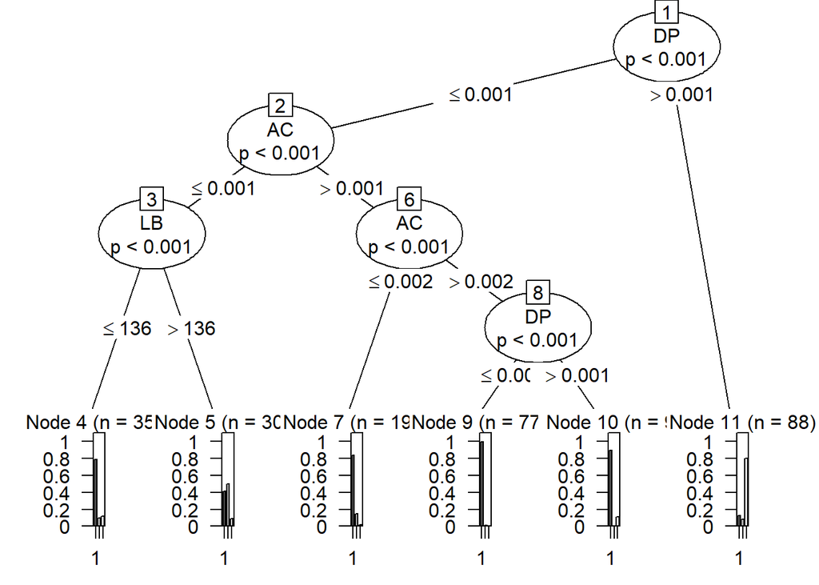

```r
plot(tree)
```

## Decision tree with rpart

```r
library(rpart)
str(train)
```

```
## 'data.frame':    1718 obs. of  23 variables:
##  $ LB      : int  120 132 133 134 134 134 122 122 122 151 ...
##  $ AC      : num  0 0.00638 0.00332 0.00256 0.00105 ...
##  $ FM      : num  0 0 0 0 0 0 0 0 0 0 ...
##  $ UC      : num  0 0.00638 0.00831 0.00768 0.01049 ...
##  $ DL      : num  0 0.00319 0.00332 0.00256 0.00944 ...
##  $ DS      : num  0 0 0 0 0 0 0 0 0 0 ...
##  $ DP      : num  0 0 0 0 0.0021 ...
##  $ ASTV    : int  73 17 16 16 26 29 83 84 86 64 ...
##  $ MSTV    : num  0.5 2.1 2.1 2.4 5.9 6.3 0.5 0.5 0.3 1.9 ...
##  $ ALTV    : int  43 0 0 0 0 0 6 5 6 9 ...
##  $ MLTV    : num  2.4 10.4 13.4 23 0 0 15.6 13.6 10.6 27.6 ...
##  $ Width   : int  64 130 130 117 150 150 68 68 68 130 ...
##  $ Min     : int  62 68 68 53 50 50 62 62 62 56 ...
##  $ Max     : int  126 198 198 170 200 200 130 130 130 186 ...
##  $ Nmax    : int  2 6 5 11 5 6 0 0 1 2 ...
##  $ Nzeros  : int  0 1 1 0 3 3 0 0 0 0 ...
##  $ Mode    : int  120 141 141 137 76 71 122 122 122 150 ...
##  $ Mean    : int  137 136 135 134 107 107 122 122 122 148 ...
##  $ Median  : int  121 140 138 137 107 106 123 123 123 151 ...
##  $ Variance: int  73 12 13 13 170 215 3 3 1 9 ...
##  $ Tendency: int  1 0 0 1 0 0 1 1 1 1 ...
##  $ NSP     : int  2 1 1 1 3 3 3 3 3 2 ...
##  $ NSPF    : Factor w/ 3 levels "1","2","3": 2 1 1 1 3 3 3 3 3 2 ...
```

```r
head(na.omit(train))
```

```
##    LB          AC FM          UC          DL DS          DP ASTV MSTV ALTV MLTV
## 1 120 0.000000000  0 0.000000000 0.000000000  0 0.000000000   73  0.5   43  2.4
## 2 132 0.006379585  0 0.006379585 0.003189793  0 0.000000000   17  2.1    0 10.4
## 3 133 0.003322259  0 0.008305648 0.003322259  0 0.000000000   16  2.1    0 13.4
## 4 134 0.002560819  0 0.007682458 0.002560819  0 0.000000000   16  2.4    0 23.0
## 6 134 0.001049318  0 0.010493179 0.009443861  0 0.002098636   26  5.9    0  0.0
## 7 134 0.001402525  0 0.012622721 0.008415147  0 0.002805049   29  6.3    0  0.0
##   Width Min Max Nmax Nzeros Mode Mean Median Variance Tendency NSP NSPF
## 1    64  62 126    2      0  120  137    121       73        1   2    2
## 2   130  68 198    6      1  141  136    140       12        0   1    1
## 3   130  68 198    5      1  141  135    138       13        0   1    1
## 4   117  53 170   11      0  137  134    137       13        1   1    1
## 6   150  50 200    5      3   76  107    107      170        0   3    3
## 7   150  50 200    6      3   71  107    106      215        0   3    3
```

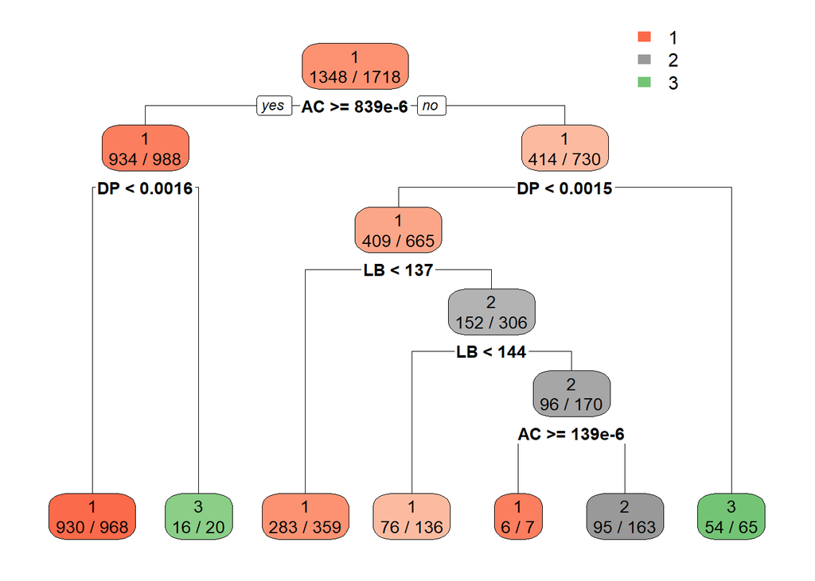

```r
tree1 <- rpart(NSPF~LB+AC+DP, train)
library(rpart.plot)
rpart.plot(tree1,extra=2)
```

```r
#prediction
head(predict(tree1,validate))
```

```
##            1          2           3
## 5  0.9607438 0.03409091 0.005165289
## 14 0.9607438 0.03409091 0.005165289
## 16 0.9607438 0.03409091 0.005165289
## 26 0.7883008 0.09749304 0.114206128
## 28 0.7883008 0.09749304 0.114206128
## 29 0.7883008 0.09749304 0.114206128
```

## Misclassifcation error for train data

```r
tab <- table(predict(tree),train$NSPF)
print(tab)
```

```
##
##        1    2    3
##   1 1214   69   46
##   2  123  150   28
##   3   11    7   70
```

## Misclassification error with validate data

```r
testPred <- predict(tree,newdata=validate)
tab <- table(testPred,validate$NSPF)
print(tab)
```

```
##
## testPred   1   2   3
##        1 273  20  13
##        2  29  46   4
##        3   5   3  15
```